# Introduction to using and programming with NIMBLE models

UW 2020 short course

NIMBLE Development Team

# Models as graphs

- Ecologists and many statisticians speak of “hierarchical models”.
- Computer scientists and others sometimes speak of “graphical models”.
- A hierarchical model is typically a directed acyclic graph (DAG).

# NIMBLE models as objects

When you create a NIMBLE model, it is an object in R.

You can:

- Get or set parameter or data values.
- Determine graph relationships.
- Calculate log probabilities.
- Simulate (draw) from distributions.
- More.

# Linear regression example

Let’s use a really simple model:

- Linear regression with 4 data points.

```r
set.seed(2468)
mc <- nimbleCode({
    intercept ~ dnorm(0, sd = 1000)
    slope ~ dnorm(0, sd = 1000)
    sigma ~ dunif(0, 100)
    for(i in 1:4) {
        predicted.y[i] <- intercept + slope * x[i]
        y[i] ~ dnorm(predicted.y[i], sd = sigma)
    }
})
model <- nimbleModel(mc,
                     data = list(y = rnorm(4)),
                     inits = list(intercept = 0.5,
                                  slope = 0.2,
                                  sigma = 1,
                                  x = c(0.1, 0.2, 0.3, 0.4)))
```

```
## defining model...
```

```
## building model...
```

```
## setting data and initial values...
```

```
## running calculate on model (any error reports that follow may simply reflect missing values in model variables) ...
## checking model sizes and dimensions...
## model building finished.
```

# Draw the graph:

This was done with package `igraph`.

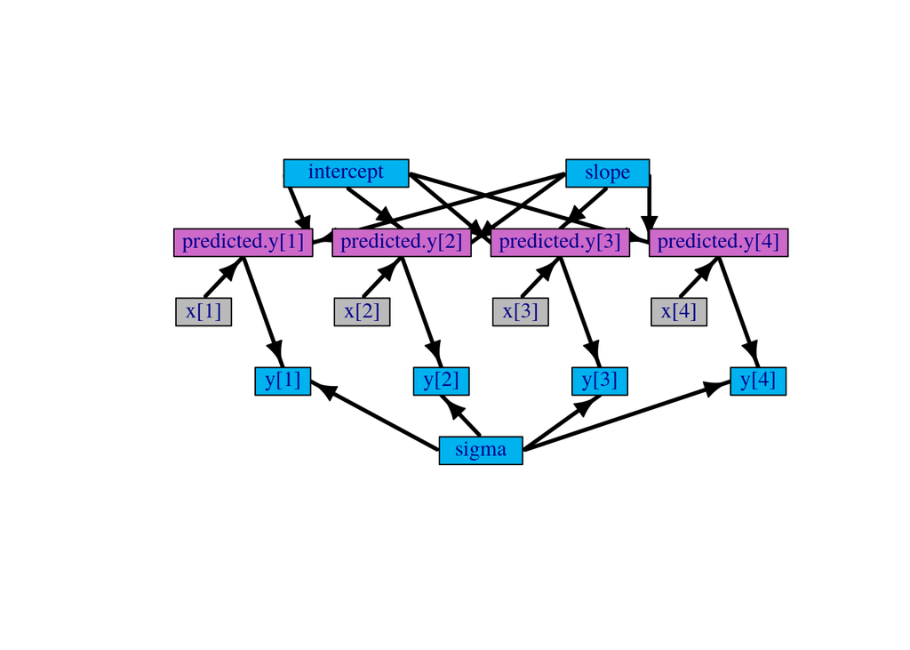

- Think of each line of BUGS language code as declaring one or more *nodes*.

# Get and set values

This is done in natural R syntax.

```r
model$sigma
```

```
## [1] 1
```

```r
model$x
```

```
## [1] 0.1 0.2 0.3 0.4
```

```r
model$x[3] <- 0.6
model$x
```

```
## [1] 0.1 0.2 0.6 0.4
```

This can be done with a compiled model too.

# You can even get and set data values

```r
model$y
```

```
## [1] -0.0939556 -0.3191924 -0.7556346  0.4589819
```

```r
model$y[1] <- 0.8
model$y
```

```
## [1]  0.8000000 -0.3191924 -0.7556346  0.4589819
```

# Get names of nodes in the graph

```r
model$getNodeNames()
```

```
##  [1] "intercept"      "slope"          "sigma"          "predicted.y[1]"
##  [5] "predicted.y[2]" "predicted.y[3]" "predicted.y[4]" "y[1]"
##  [9] "y[2]"           "y[3]"           "y[4]"
```

## Get types of nodes

```r
model$getNodeNames(dataOnly = TRUE)
```

```
## [1] "y[1]" "y[2]" "y[3]" "y[4]"
```

```r
model$getNodeNames(determOnly = TRUE)
```

```
## [1] "predicted.y[1]" "predicted.y[2]" "predicted.y[3]" "predicted.y[4]"
```

```r
model$isData('y')
```

```
## [1] TRUE TRUE TRUE TRUE
```

# Get node relationships

```r
model$getDependencies("x[2]")
```

```
## [1] "predicted.y[2]" "y[2]"
```

```r
model$getDependencies("sigma")
```

```
## [1] "sigma" "y[1]"  "y[2]"  "y[3]"  "y[4]"
```

```r
model$getDependencies("slope")
```

```
## [1] "slope"          "predicted.y[1]" "predicted.y[2]" "predicted.y[3]"
## [5] "predicted.y[4]" "y[1]"           "y[2]"           "y[3]"
## [9] "y[4]"
```

# Why do node relationships matter?

For typical MCMC samplers, `model$getDependencies('beta[1]')` returns the nodes that need to be calculated when sampling `beta[1]`.

Results from `model$getDependencies` are in *topologically sorted* order:

- If you calculate them in order, you’ll get correct results.
- E.g., `predicted.y[2]` comes before `y[2]`.

# Nodes vs. variables

In NIMBLE:

- A variable is an object that may contain multiple nodes.
  - `y` is a variable.
- A node is a part of a variable declared in one line of BUGS code.
  - `y[1]` … `y[4]` are scalar nodes.

Some other definitions:

- parameter: an unknown quantity in the model that is represented as a random variable and will generally be estimated in an algorithm, e.g. `slope` in the regresson model
- data: a known quantity in a model, also represented as a random variable, e.g., `y[1], ..., y[4]`
- constants: other fixed quantities involved in the model, e.g., `M` in the occupancy model.litters model
- node: an element in the model graph representing data, parameter, or a deterministic quantity that is a function of other quantities in the model, e.g., `y[1]`, `z[3]` or `beta1` in the occupancy model, or `y[1, 1:J]` in the marginalized occupancy model
- variable: a collection of one or more nodes with the same name, e.g., *z* or *y* in the occupancy model

# How vectorizing changes nodes

```r
mc2 <- nimbleCode({
    intercept ~ dnorm(0, sd = 1000)
    slope ~ dnorm(0, sd = 1000)
    sigma ~ dunif(0, 100)
    predicted.y[1:4] <- intercept + slope * x[1:4] #vectorized
    for(i in 1:4) {
        y[i] ~ dnorm(predicted.y[i], sd = sigma)
    }
})
model2 <- nimbleModel(mc2,
                      data = list(y = rnorm(4)),
                      inits = list(intercept = 0.5,
                                  slope = 0.2,
                                  sigma = 1,
                                  x = c(0.1, 0.2, 0.3, 0.4)))
```

```
## defining model...
```

```
## building model...
```

```
## setting data and initial values...
```

```
## running calculate on model (any error reports that follow may simply reflect missing values in model variables) ...
## checking model sizes and dimensions...
## model building finished.
```

## Look at nodes in the vectorized model:

```r
model2$getNodeNames()
```

```
## [1] "intercept"        "slope"            "sigma"
## [4] "predicted.y[1:4]" "y[1]"             "y[2]"
## [7] "y[3]"             "y[4]"
```

```r
model2$getDependencies('x[2]')
```

```
## [1] "predicted.y[1:4]" "y[1]"             "y[2]"
## [4] "y[3]"             "y[4]"
```

In this case, if `x[2]` had a prior and was being sampled in MCMC, it would be inefficient to calculate all of `y[1:4]`.

# Log probability calculations

```r
model$calculate('y[1:4]')
```

```
## [1] -4.95683
```

This is the sum of log probabilities of all stochastic nodes in the calculation.

- Deterministic nodes have their values calculated but contribute 0 to the log probability.

```r
model$calculate( model$getDependencies('intercept'))
```

```
## [1] -12.86426
```

In this case, this is the sum of log probabilities from almost the entire model.

Only the priors for `slope` and `sigma` are not included.

# Simulating from the model

In this model, there are no random effects. The only stochastic nodes are parameters with priors or data.

```r
model$sigma
```

```
## [1] 1
```

```r
model$simulate('sigma')
model$sigma
```

```
## [1] 22.7496
```

Data values are protected from simulation unless you are sure.

(The following is not good model-generic programming. See below.)

```r
model$y
```

```
## [1]  0.8000000 -0.3191924 -0.7556346  0.4589819
```

```r
model$simulate('y') ## Will not over-write data nodes
```

```r
model$y
```

```
## [1]  0.8000000 -0.3191924 -0.7556346  0.4589819
```

```r
model$simulate('y', includeData = TRUE) ## will over-write data nodes
model$y
```

```
## [1] -25.67480  61.85636  10.04617 -15.95637
```

# Understanding *lifted nodes*

Consider the following version of our linear regression model, using `sigma2` rather than `sigma`.

There is no `predicted.y[i]`. The expression from that is directly in the `dnorm` for `y[i]`.

```r
mc3 <- nimbleCode({
    intercept ~ dnorm(0, sd = 1000)
    slope ~ dnorm(0, sd = 1000)
    sigma2 ~ dunif(0, 100)
    for(i in 1:4) {
        y[i] ~ dnorm(intercept + slope * x[i], var = sigma2)
    }
})
model3 <- nimbleModel(mc3,
                      data = list(y = rnorm(4)),
                      inits = list(intercept = 0.5,
                                  slope = 0.2,
                                  sigma2 = 1,
                                  x = c(0.1, 0.2, 0.3, 0.4)))
```

```
## defining model...
```

```
## building model...
```

```
## setting data and initial values...
```

```
## running calculate on model (any error reports that follow may simply reflect missing values in model variables) ...
## checking model sizes and dimensions...
## model building finished.
```

## Look at the nodes

```r
model3$getNodeNames()
```

```
##  [1] "intercept"
##  [2] "slope"
##  [3] "sigma2"
##  [4] "lifted_sqrt_oPsigma2_cP"
##  [5] "lifted_intercept_plus_slope_times_x_oBi_cB_L5[1]"
##  [6] "lifted_intercept_plus_slope_times_x_oBi_cB_L5[2]"
##  [7] "lifted_intercept_plus_slope_times_x_oBi_cB_L5[3]"
##  [8] "lifted_intercept_plus_slope_times_x_oBi_cB_L5[4]"
##  [9] "y[1]"
## [10] "y[2]"
## [11] "y[3]"
## [12] "y[4]"
```

NIMBLE has created nodes in the role of `predicted.y[i]`. It has also created a node for the standard deviation of errors that go into the data.

These are called *lifted nodes*. There were created by lifting an expression out of a parameter for a distribution and creating a deterministic node for that expression.

# Model-generic programming: concrete example

If we change `sigma2` and then directly try to work with `y`, we’ll cause (silent errors) because the lifted standard deviation has not been updated.

```r
model3$sigma2 <- 100
model3$lifted_sqrt_oPsigma2_cP
```

```
## [1] 1
```

```r
model3$simulate('y', includeData = TRUE)
summary(model3$y)
```

```
##    Min. 1st Qu.  Median    Mean 3rd Qu.    Max.
## 0.07106 0.34697 0.62859 0.77281 1.05443 1.76300
```

```r
depNodes <- model3$getDependencies('sigma2', self = FALSE)
depNodes
```

```
## [1] "lifted_sqrt_oPsigma2_cP" "y[1]"
## [3] "y[2]"                    "y[3]"
## [5] "y[4]"
```

```r
model3$simulate(depNodes, includeData = TRUE)
model3$lifted_sqrt_oPsigma2_cP
```

```
## [1] 10
```

```r
summary(model3$y)
```

```
##    Min. 1st Qu.  Median    Mean 3rd Qu.    Max.
## -13.757  -8.437  -6.233  -7.383  -5.178  -3.308
```

# Model-generic programming: More generally…

Say we want a function that simulates all parts of a model that depend on some input nodes and then returns the corresponding summed log probability. I will call this part of the model “downstream”.

```r
simulate_downstream <- function(model, nodes) {
  downstream_nodes <- model$getDependencies(nodes, downstream = TRUE)
  model$simulate( downstream_nodes, includeData = TRUE )
  logProb <- model$calculate( downstream_nodes )
  logProb
}
```

Notice that this function will work with *any* model and *any* set of input nodes.

```r
model$y
```

```
## [1] -25.67480  61.85636  10.04617 -15.95637
```

```r
simulate_downstream(model3, 'sigma2')
```

```
## [1] -18.0496
```

```r
model$y
```

```
## [1] -25.67480  61.85636  10.04617 -15.95637
```

In this case, the model doesn’t have much hierarchical structure.

# Always use graph structure in model-generic programming

You may not know where there are lifted nodes.

Always determine what to `calculate` or `simulate` from `getDependencies` or other such tools.